# ESM244 Assignment 3 Task 1

Anna Abelman

2/29/2020

```r
#read in data
stream <- read_csv("sbc_lter_registered_stream_chemistry.csv",
                   na = c("-999.0","-999"))
```

# Santa Barbara Creek Water Chemistry

### PCA Analysis

```r
#look at the number of observations in each site
stream_site_count <- stream %>%
  count(site_code)

#filtering out site to only contain AB00, AT07, RG01
stream_site <- stream %>%
  select(site_code, nh4_uM:po4_uM, tss_mgperLiter, spec_cond_uSpercm) %>%
  filter(site_code %in% c("AB00", "AT07", "RG01")) %>%
  drop_na()

stream_pca <- stream_site %>%
  select(-site_code)

#pca analysis
my_pca_stream <- prcomp(stream_pca, scale = TRUE)
summary(my_pca_stream)
```

```
## Importance of components:
##                           PC1    PC2    PC3    PC4    PC5
## Standard deviation     1.2719 1.2025 0.8827 0.7860 0.7344
## Proportion of Variance 0.3236 0.2892 0.1558 0.1235 0.1079
## Cumulative Proportion  0.3236 0.6128 0.7686 0.8921 1.0000
```

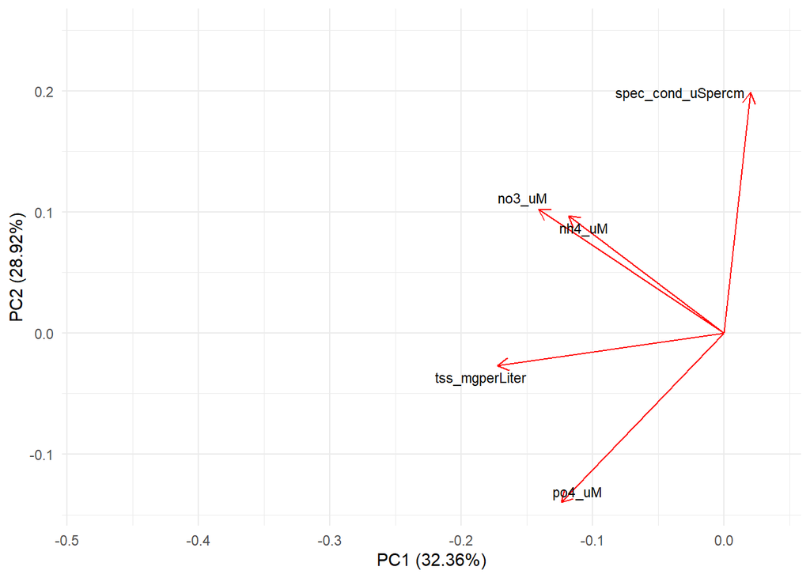

```r
#biplot it
my_biplot <- autoplot(my_pca_stream,
                      colour = NA,
                      loadings.label = TRUE,
                      loadings.label.size = 3,
                      loadings.label.colour = "black",
                      loadings.label.repel = TRUE) +
  theme_minimal()


my_biplot
```

**Figure 1**: Principal Components Analysis Bioplot demonstrating the correlations between the different stream variables. Data from: SBC LTER & Melack, 2019

Based on the PCA Analysis, the two stream variables NO3 and NH4 concentrations are positively correlated because their arrows are closer together. However, PO4 concentration and specific conductivity of the stream are negatively correlated since their arrows are going in opposite directions. Specific conductivity and total suspended solids have no correlation according to the biplot.

### Cluster Analysis

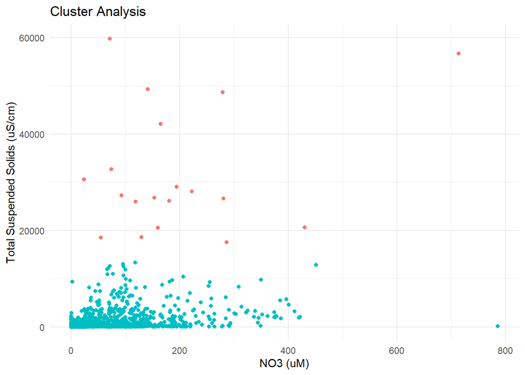

```r
#create a dataframe with the cluster results as a column
stream_cl <- data.frame(stream_pca, cluster_no = factor(stream_km$cluster))

#visualize it just looking at NO3 (uM) concentration only
ggplot(stream_cl)+
  geom_point(aes(x = no3_uM, y = tss_mgperLiter, color = cluster_no),
             show.legend = FALSE)+
  theme_minimal()+
  labs(title = "Cluster Analysis", x = "NO3 (uM)", y = "Total Suspended Solids (uS/cm)")
```

### Multiple Linear Regression

```r
#look at the correlations between the variables
# stream_cor <- cor(stream_site[2:6])
# stream_cor
#
# corrplot(stream_cor,
#          method = "circle",
#          type = "upper")
```

Table 1: Multiple Linear Regression results for suspended sediments with predictor variables: concentration (uM) of NH4, NO3, and PO4, the stream conductivity (uS/cm). Data from: SBC LTER & Melack, 2019

```r
#create a multiple regression model to see how the site, nh4, no3, po4, and conductibity has on the suspended sediments
stream_lm <- lm(tss_mgperLiter ~ site_code + nh4_uM + no3_uM + po4_uM + spec_cond_uSpercm, data = stream_site)

#summary(stream_lm)

stream_lm2 <- lm(tss_mgperLiter ~ site_code + nh4_uM + no3_uM + po4_uM, data = stream_site)

#summary(stream_lm2)

stream_lm3 <- lm(tss_mgperLiter ~ nh4_uM + no3_uM + po4_uM + spec_cond_uSpercm, data = stream_site)

#summary(stream_lm3)

stream_lm4 <- lm(tss_mgperLiter ~ site_code + no3_uM + po4_uM + spec_cond_uSpercm, data = stream_site)

#summary(stream_lm4)

stream_lm5 <- lm(tss_mgperLiter ~ site_code + no3_uM + spec_cond_uSpercm + nh4_uM , data = stream_site)

#summary(stream_lm5)

#AIC
# AIC(stream_lm)
# AIC(stream_lm2)
# AIC(stream_lm3)
# AIC(stream_lm4)
# AIC(stream_lm5)

stargazer(stream_lm, type = "html")
```

|  | *Dependent variable:* |
| --- | --- |
|  | tss_mgperLiter |
| site_codeAT07 | -3,155.657* |
|  | (1,666.480) |
| site_codeRG01 | 3,724.599*** |
|  | (389.377) |
| nh4_uM | 91.804*** |
|  | (13.237) |
| no3_uM | 4.796** |
|  | (1.877) |
| po4_uM | 206.843*** |
|  | (20.438) |
| spec_cond_uSpercm | -0.674*** |
|  | (0.240) |
| Constant | -559.555** |
|  | (277.839) |
| Observations | 1,190 |
| R<sup>2</sup> | 0.253 |
| Adjusted R<sup>2</sup> | 0.250 |
| Residual Std. Error | 4,015.794 (df = 1183) |
| F Statistic | 66.917*** (df = 6; 1183) |
| *Note:* | p<0.1; p<0.05; p<0.01 |

The multiple linear regression model indicates that the site AT07 has a negative effect on the total suspended solids, while the site RG01 has a positive correlation. The three concentrations: NH4, NO3, and PO4 all have positive correlation on total suspended solids and the specific conductivity has a slightly negative correlation. This differs from the PCA analysis above (Figure 1).

Citation:

Santa Barbara Coastal LTER and J. Melack. 2019. SBC LTER: Land: Stream chemistry in the Santa Barbara Coastal drainage area, ongoing since 2000 ver 16. Environmental Data Initiative. https://doi.org/10.6073/pasta/67a558a24ceed9a0a5bf5e46ab841174. Accessed 2020-03-10.